# Part I - FIFA Player Statistics

## Introduction

> This dataset contains data on different football players and their capabilities as per the video game FIFA 19.

## Preliminary Wrangling

```python
# import all packages and set plots to be embedded inline
import numpy as np
import pandas as pd
import matplotlib.pyplot as plt
import seaborn as sb

%matplotlib inline
```

> Load in your dataset and describe its properties through the questions below. Try and motivate your exploration goals through this section.

```python
#load the dataset into a pandas dataframe
df = pd.read_csv('data.csv')
df.head()
```

|  | Unnamed: 0 | ID | Name | Age | Photo | Nationality | Flag | Overall | Potential | Club | ... | Composure | Marking | StandingTackle | SlidingTackle | GKDiving | GKHandling | GKKicking | GKPositioning | GKReflexes | Release Clause |
| --- | --- | --- | --- | --- | --- | --- | --- | --- | --- | --- | --- | --- | --- | --- | --- | --- | --- | --- | --- | --- | --- |
| 0 | 0 | 158023 | L. Messi | 31 | https://cdn.sofifa.org/players/4/19/158023.png | Argentina | https://cdn.sofifa.org/flags/52.png | 94 | 94 | FC Barcelona | ... | 96.0 | 33.0 | 28.0 | 26.0 | 6.0 | 11.0 | 15.0 | 14.0 | 8.0 | €226.5M |
| 1 | 1 | 20801 | Cristiano Ronaldo | 33 | https://cdn.sofifa.org/players/4/19/20801.png | Portugal | https://cdn.sofifa.org/flags/38.png | 94 | 94 | Juventus | ... | 95.0 | 28.0 | 31.0 | 23.0 | 7.0 | 11.0 | 15.0 | 14.0 | 11.0 | €127.1M |
| 2 | 2 | 190871 | Neymar Jr | 26 | https://cdn.sofifa.org/players/4/19/190871.png | Brazil | https://cdn.sofifa.org/flags/54.png | 92 | 93 | Paris Saint-Germain | ... | 94.0 | 27.0 | 24.0 | 33.0 | 9.0 | 9.0 | 15.0 | 15.0 | 11.0 | €228.1M |
| 3 | 3 | 193080 | De Gea | 27 | https://cdn.sofifa.org/players/4/19/193080.png | Spain | https://cdn.sofifa.org/flags/45.png | 91 | 93 | Manchester United | ... | 68.0 | 15.0 | 21.0 | 13.0 | 90.0 | 85.0 | 87.0 | 88.0 | 94.0 | €138.6M |
| 4 | 4 | 192985 | K. De Bruyne | 27 | https://cdn.sofifa.org/players/4/19/192985.png | Belgium | https://cdn.sofifa.org/flags/7.png | 91 | 92 | Manchester City | ... | 88.0 | 68.0 | 58.0 | 51.0 | 15.0 | 13.0 | 5.0 | 10.0 | 13.0 | €196.4M |

5 rows × 89 columns

```python
#display dataset information
df.info()
```

```
<class 'pandas.core.frame.DataFrame'>
RangeIndex: 18207 entries, 0 to 18206
Data columns (total 89 columns):
 #   Column                    Non-Null Count  Dtype
---  ------                    --------------  -----
 0   Unnamed: 0                18207 non-null  int64
 1   ID                        18207 non-null  int64
 2   Name                      18207 non-null  object
 3   Age                       18207 non-null  int64
 4   Photo                     18207 non-null  object
 5   Nationality               18207 non-null  object
 6   Flag                      18207 non-null  object
 7   Overall                   18207 non-null  int64
 8   Potential                 18207 non-null  int64
 9   Club                      17966 non-null  object
```

[output cut: 81 more lines]

```python
#describe dataset statistics
df.describe()
```

|  | Unnamed: 0 | ID | Age | Overall | Potential | Special | International Reputation | Weak Foot | Skill Moves | Jersey Number | ... | Penalties | Composure | Marking | StandingTackle | SlidingTackle | GKDiving | GKHandling | GKKicking | GKPositioning | GKReflexes |
| --- | --- | --- | --- | --- | --- | --- | --- | --- | --- | --- | --- | --- | --- | --- | --- | --- | --- | --- | --- | --- | --- |
| count | 18207.000000 | 18207.000000 | 18207.000000 | 18207.000000 | 18207.000000 | 18207.000000 | 18159.000000 | 18159.000000 | 18159.000000 | 18147.000000 | ... | 18159.000000 | 18159.000000 | 18159.000000 | 18159.000000 | 18159.000000 | 18159.000000 | 18159.000000 | 18159.000000 | 18159.000000 | 18159.000000 |
| mean | 9103.000000 | 214298.338606 | 25.122206 | 66.238699 | 71.307299 | 1597.809908 | 1.113222 | 2.947299 | 2.361308 | 19.546096 | ... | 48.548598 | 58.648274 | 47.281623 | 47.697836 | 45.661435 | 16.616223 | 16.391596 | 16.232061 | 16.388898 | 16.710887 |
| std | 5256.052511 | 29965.244204 | 4.669943 | 6.908930 | 6.136496 | 272.586016 | 0.394031 | 0.660456 | 0.756164 | 15.947765 | ... | 15.704053 | 11.436133 | 19.904397 | 21.664004 | 21.289135 | 17.695349 | 16.906900 | 16.502864 | 17.034669 | 17.955119 |
| min | 0.000000 | 16.000000 | 16.000000 | 46.000000 | 48.000000 | 731.000000 | 1.000000 | 1.000000 | 1.000000 | 1.000000 | ... | 5.000000 | 3.000000 | 3.000000 | 2.000000 | 3.000000 | 1.000000 | 1.000000 | 1.000000 | 1.000000 | 1.000000 |
| 25% | 4551.500000 | 200315.500000 | 21.000000 | 62.000000 | 67.000000 | 1457.000000 | 1.000000 | 3.000000 | 2.000000 | 8.000000 | ... | 39.000000 | 51.000000 | 30.000000 | 27.000000 | 24.000000 | 8.000000 | 8.000000 | 8.000000 | 8.000000 | 8.000000 |
| 50% | 9103.000000 | 221759.000000 | 25.000000 | 66.000000 | 71.000000 | 1635.000000 | 1.000000 | 3.000000 | 2.000000 | 17.000000 | ... | 49.000000 | 60.000000 | 53.000000 | 55.000000 | 52.000000 | 11.000000 | 11.000000 | 11.000000 | 11.000000 | 11.000000 |
| 75% | 13654.500000 | 236529.500000 | 28.000000 | 71.000000 | 75.000000 | 1787.000000 | 1.000000 | 3.000000 | 3.000000 | 26.000000 | ... | 60.000000 | 67.000000 | 64.000000 | 66.000000 | 64.000000 | 14.000000 | 14.000000 | 14.000000 | 14.000000 | 14.000000 |
| max | 18206.000000 | 246620.000000 | 45.000000 | 94.000000 | 95.000000 | 2346.000000 | 5.000000 | 5.000000 | 5.000000 | 99.000000 | ... | 92.000000 | 96.000000 | 94.000000 | 93.000000 | 91.000000 | 90.000000 | 92.000000 | 91.000000 | 90.000000 | 94.000000 |

8 rows × 44 columns

### What is the structure of your dataset?

The dataset consists of 18207 rows and 89 columns. Some columns have missing values. Column 28 to 53 which consist of player position information have missing values. Columns Release Clause, Joined, Loaned From and Contract Valid Until also have a substantial amount of missing values.

### What is/are the main feature(s) of interest in your dataset?

My interest is to show relationships between different characteristics and stats of the players and also to show how the most valuable players rank against each other.

### What features in the dataset do you think will help support your investigation into your feature(s) of interest?

A number of characteristics available in the dataset will be useful in my investigation. Some of them including BallControl, Strength, Agility, Age, Balance, Stamina etc. The dataset is large so it will be fun exploring all these variables.

## Univariate Exploration

In this section, I explored individual variables in the dataset and their distribution. Some of the questions I asked myself were:

1. Which country do most players come from? To answer This question, I used the variable Nationality.
2. What age are most players in the game and what is the average age of players? Variable in use was Age.
3. Which is the most preferred foot foot by most players? Variable in use was Preferred Foot
4. Which overall rating did most players fall in?
5. Which positions had the most players?

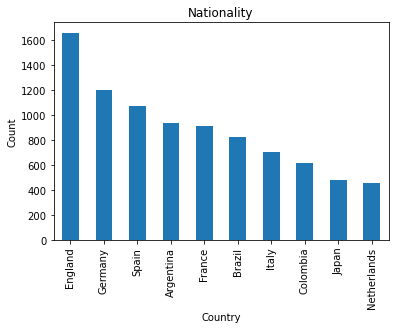

```python
#plotting top five countries with the highest number of players
df.Nationality.value_counts().head(10).plot(kind='bar',xlabel='Country', ylabel='Count', title= 'Nationality')
```

From the above graph, we see that the highest number of players come from England. The the top ten countries with the highest players, six are in Europe with Argentina, Brazil, Colombia and Japan being those outside Europe.

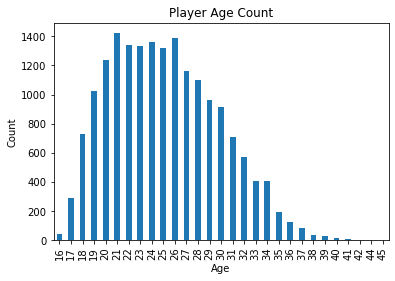

```python
#plotting the age distribution of players
df.Age.value_counts().sort_index(ascending=True).plot(kind='bar',xlabel= 'Age', ylabel= 'Count', title= 'Player Age Count')
```

From the above graph, we see a high number of players' ages are between the range of 19 and 28 years. The highest number of players being of age 21. We also see the youngest player being of age 16 and the oldest being above 41.

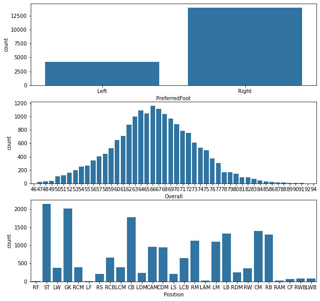

```python
#plotting th distribution of variables Preferred Foot,Overall rating and Position played by player.
fig, ax = plt.subplots(nrows=3, figsize = [10,10])
default_color = sb.color_palette()[0]
sb.countplot(data = df, x = 'PreferredFoot', color = default_color, ax = ax[0])
sb.countplot(data = df, x = 'Overall', color = default_color, ax = ax[1])
sb.countplot(data = df, x = 'Position', color = default_color, ax = ax[2])
plt.show()
```

From the above plots, we gather that most players' preferred foot is their right foot with some players having the left foot as their preferred foot for playing. We also see that a high number of players in the game fall under an overall rating of 66 with most players distributed between ratings of 60 and 72. We also learn that a high number of players in the game play striker(ST) positions followed by goalkeepers (GK) then center back (CB) positions.

[figure not shown]

```python
#plotting Skill Moves and Dribbling
def plot_1():
    """Plot the variables Skill Moves and Dribbling."""
    df = pd.read_csv('data.csv')
    fig, ax = plt.subplots(nrows=2, figsize = [9,8])
    variables = ['Skill Moves', 'Dribbling']
    for i in range(len(variables)):
        var = variables[i]
        bins = np.arange(min(df[var]), max(df[var])+0.2, 0.2)
        ax[i].hist(data = df, x = var, bins = bins)
        ax[i].set_xlabel('{}'.format(var))

    plt.show()
```

The above plot shows the distribution on Player Dribbling ability and Skill moves. We see that most players fall between 50 and 80 in Dribbling and between 2.0 and 3.3 in Skill Moves.

### Discuss the distribution(s) of your variable(s) of interest. Were there any unusual points? Did you need to perform any transformations?

The distribution of the variables in my investigation was different for different variables. Most seemed regular with few to null unusual points. No data transformation was required before my analysis as the data available was clean.

### Of the features you investigated, were there any unusual distributions? Did you perform any operations on the data to tidy, adjust, or change the form of the data? If so, why did you do this?

There were no unusual distributions in te features i investigated. The variables I used for my investigation did not require any tidying or adjustment.

## Bivariate Exploration

I start by checking the correlation of different variables and abilities of differnt players and see how one affects the other.

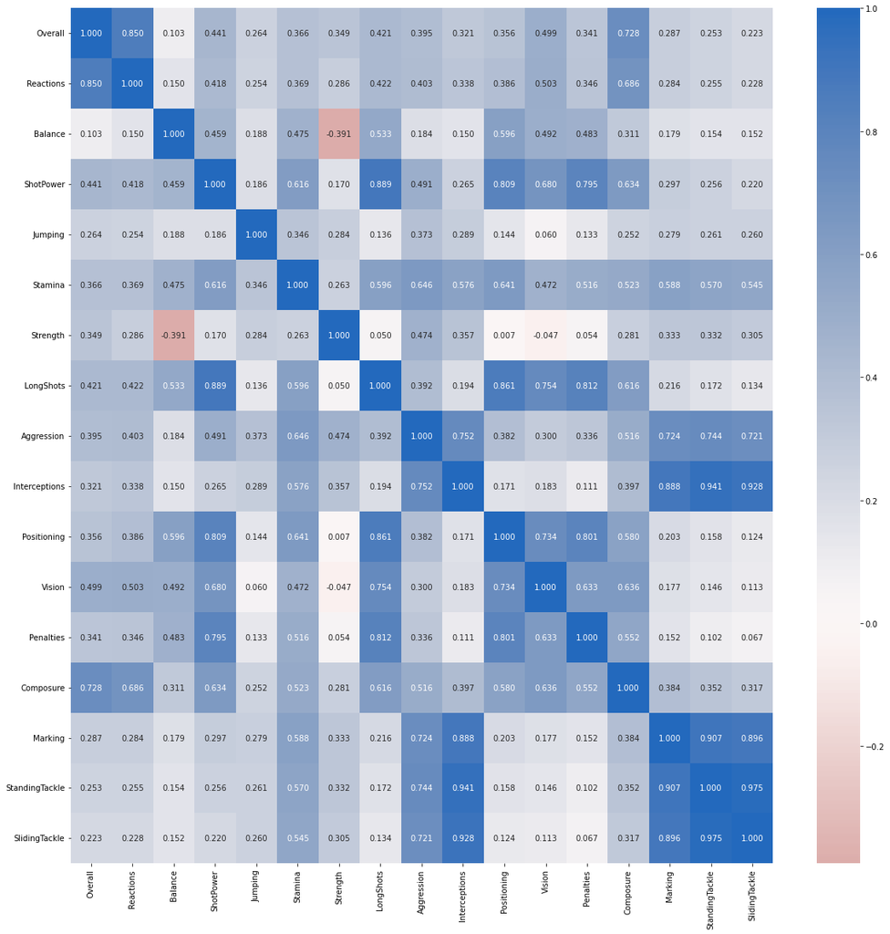

```python
#Plotting a correlation heat map
numeric_variables = ['Overall','Reactions','Balance','ShotPower','Jumping','Stamina','Strength','LongShots','Aggression','Interceptions','Positioning','Vision','Penalties','Composure','Marking','StandingTackle','SlidingTackle']
plt.figure(figsize = [20, 20])
sb.heatmap(df[numeric_variables].corr(), annot = True, fmt = '.3f',
           cmap = 'vlag_r', center = 0)
plt.show()
```

Due to the number of variables not being able to fit in one chart and be visible, I divided the data into two charts for easy assessment and better visibility. As we know, there is stronger correlation between two variables when the correlation coefficient is closer to 1 or -1 and weaker as it goes to 0. Frome above chart, we see a strong correlation between a number of attributes/variable. For example:

> Sliding Tackle, Standing Tackle and Marking have a strong correlation with interceptions. Sliding Tackle and Standing Tackle have a strong correlation. We also see a strong correlation between ShotPower and LongShot, Penalties and LongShots, Positioning and LongShots, Reactions and Overall, Penalties and Positioning. We see no variables with a strong negative correlation.

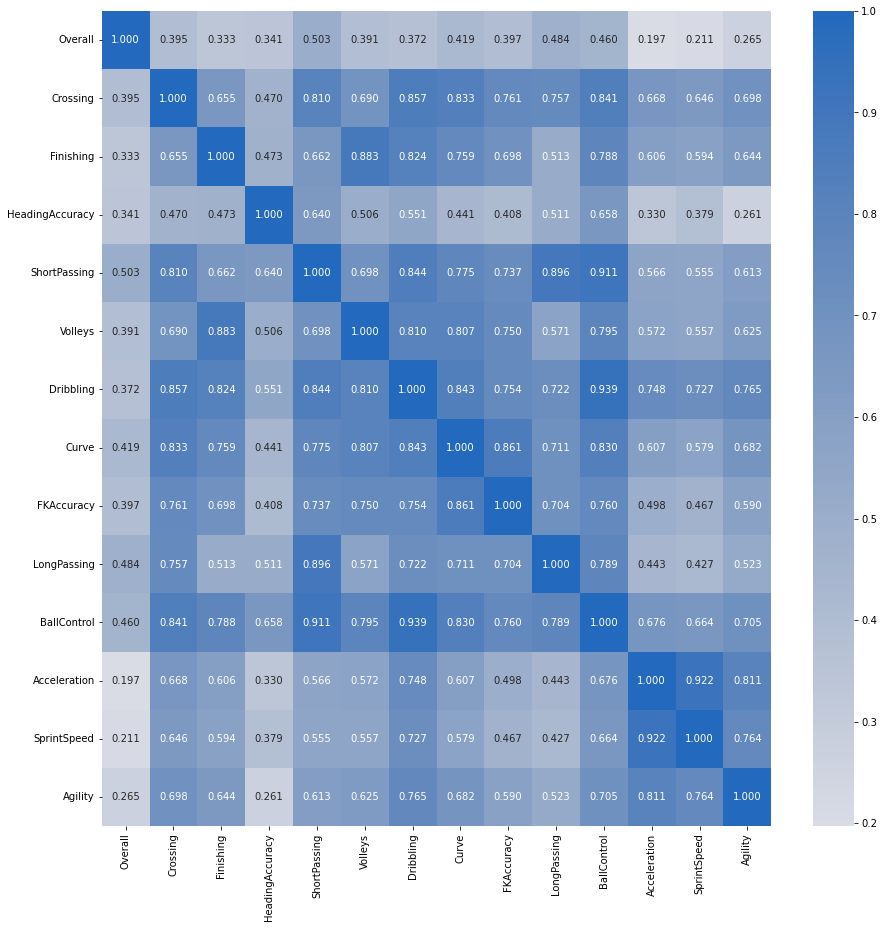

```python
#plotting the second group of variables
numeric_variables=['Overall','Crossing','Finishing','HeadingAccuracy','ShortPassing','Volleys','Dribbling','Curve','FKAccuracy','LongPassing','BallControl','Acceleration','SprintSpeed','Agility']
plt.figure(figsize = [15, 15])
sb.heatmap(df[numeric_variables].corr(), annot = True, fmt = '.3f',
           cmap = 'vlag_r', center = 0)
plt.show()
```

In this group, we see a large number of variables having a STRONG correlation. These variables are:

1.Ball Control and Short Passing

2.Ball Control and Dribbling

3.Ball Control and Curve

4.Sprint Speed and Acceleration

5.FKAccuracy and Curve

6.Agility and Acceleration

7.Crossing and Dribbling

8.Crossing and Curve

9.Dribbling and Curve

10.Finishing and Dribbling

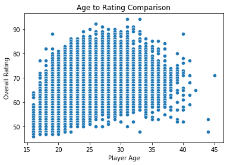

```python
#plotting Age to Rating distribution
sb.scatterplot(data = df, x = 'Age', y = 'Overall');
plt.xlabel('Player Age')
plt.ylabel('Overall Rating')
plt.title('Age to Rating Comparison')
```

### Talk about some of the relationships you observed in this part of the investigation. How did the feature(s) of interest vary with other features in the dataset?

We see a strong relationship between some of the variables in the correlation heatmaps. Most of which actually make sense for example Accelaration of a player having a strong correlation with Agility and speed. I have listed all the variables with strong relationships above. When it comes to the comparison between Age and Overall rating, we don't see much of a correlation as the distribution is almost even.

### Did you observe any interesting relationships between the other features (not the main feature(s) of interest)?

We see a weak correlation between Strength and Balance which I find very interesting.

## Multivariate Exploration

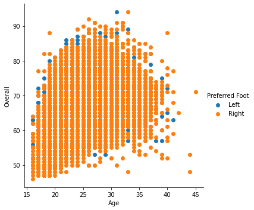

```python
#plotting preferred foot distribution
g = sb.FacetGrid(data = df, hue = 'Preferred Foot', height = 5)
g.map(plt.scatter, 'Age', 'Overall')
g.add_legend()
```

In the above graph, we have added the Preferred Foot variable to the Age vs Overall rating grating and we clearly see again that the most preferred foot is the right foot. We also see a couple of players with left foot preference having a rating of 84 and higher meaning even lefties perform on a high level despite being fewer.

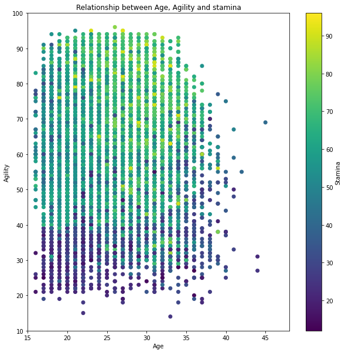

```python
# plotting relationship between Age, Agility and stamina
plt.figure(figsize = [10,10])
plt.scatter(data = df, x = 'Age', y = 'Agility',
                c = 'Stamina')
plt.colorbar(label = 'Stamina')
plt.xlim(15,48)
plt.ylim(10,100)
plt.xlabel('Age')
plt.ylabel('Agility')
plt.title('Relationship between Age, Agility and stamina')
```

In the above plot, we investigate whether age affects the agility and stamina of a player and whether older players have less stamina and agility than younger ones. In terms of Agility we see a somewhat even distribution meaning there's no strong correlation between Agility and Age. However we see a correlation between Stamina and Agility where players with lower agility also have lower stamina. We also see players above 35 generally having lower stamina.

[figure not shown]

```python
#Plotting Shot Power and Dribbling against different positions and preferred foot
g = sb.FacetGrid(data = df, col = 'PreferredFoot', row = 'Position', height = 3,
                margin_titles = True)
g.map(plt.scatter, 'ShotPower', 'Dribbling')
```

### Talk about some of the relationships you observed in this part of the investigation. Were there features that strengthened each other in terms of looking at your feature(s) of interest?

From the above plots in the grid, we gather some insights on the different positions and their abilities. Here are some of the insights I gathered:

1. We see the players in Right Forward (RF) position having strong Dribbling Skills and Shot power regardless of foot being used. However, not many players playing this position.
2. A number of players play striker (ST) position with their distribution varying but most being above average in Shot power and Dribbling.
3. Players playing Left Wing (LW) position were also above average in dribbling and shot power however there is on outlier in the shot power plot.
4. We see goalkeepers (GK) having weak dribbling and shot power capabilities which makes sense since their role does not require much skilset in the two,
5. Right Center Mid (RCM) position players have an above average ability in the two abilities.
6. Left Forward position (LF) players are few according to the distribution in the plot and above average in dribbling and shot power.
7. Right Strikers (RS) were also above average in both dribbling and shot power except a few outliers.
8. All players playing Center Back(CB) position had a rating of less than 70 in both dribbling and shot power.
9. Center Attacking Midfield (CAM) players had a similar distribution for both Left Foot and Right Foot players.
10. Most players playing Center Defensive Midfield are rightfooted.
11. Most Right Strikers(RS) have an above average Shot Power and are right footed.
12. Few players play Left Attacking Midfield (LAM) position.
13. A large number of players playing Left Back (LB) and Left Wing Back (LWB) position have their prefereed foot as the left.
14. Right Defensive Midfield(RDM), Right Back(RB) and Right Wing(RW) players mostly preferred their right foot.

### Were there any interesting or surprising interactions between features?

There was a clear correlation between Preferred foot and the position the player plays.

## Conclusions

After Exploratory Analysis of the dataset, I have come across a number of insights most of which I've listed below their respective plots. We see clear correlation between attributes of the players that seem to complement each other.